# Predicting Online Sales from Webpage Analytics

Lesley Miller, Cheng Min, Shivam Verma

24/01/2020

# Project Summary

> Here we attempt to build a classification model using the light gradient boosting algorithm which can use webpage metrics from a given online shopping website to predict whether the revenue of a new customer is True (i.e., the customer makde a purchase) or False (i.e., the customer did not make a purchase). Our final classifier performed well on an unseen test data set, with the F1 score of 0.655 and the test accuray calculated to be 91.2%. The precision and recall of our classifier on the test set are 0.709 and 0.609 respectively. Due to substantially high number of false positives & negatives, we recommend further iteration to improve this model.

# Introduction

# Methods

## Data Source

> The data set used in this project is of online shopping webpage metrics created by C. Okan Sakar, S. Olcay Polat, Mete Katircioglu & Yomi Kastro(Sakar et al. 2019). It was sourced from the UCI Machine Learning Repository (Dua and Graff 2019) and can be found [here](https://archive.ics.uci.edu/ml/datasets/Online+Shoppers+Purchasing+Intention+Dataset). Each row in the data set represents webpage metrics on a single shopper which was extracted from the URL information and includes the final action (purchase or not) and several other measurements (e.g., Number of Distinct Product Related pages, Time spent on Product Related pages, closeness of site visitng time to a special day, etc.).

## Exploratory Data Analysis

### Brief Data Summary

[Data Source Here](https://archive.ics.uci.edu/ml/datasets/Online+Shoppers+Purchasing+Intention+Dataset)

> - Each row represents a session by a single user.
> - Each user has only 1 session in the dataset.
> - The data is for a 1-year period.
> - ~15% of sessions result in a purchase.
> - Predictive variables included in this analysis are user’s visit information, web analytics features & geographic features. See data description table for more details about each variable used in the model.

### Description of the Variables

[Data Source Here](https://archive.ics.uci.edu/ml/datasets/Online+Shoppers+Purchasing+Intention+Dataset)

| No. | Variable | Description |
| --- | --- | --- |
| 1 | `Administrative` | Number of Distinct administrative pages |
| 2 | `Informational` | Number of Distinct Informational pages |
| 3 | `ProductRelated` | Number of Distinct Product Related pages |
| 4 | `Administrative_Duration` | Time(in seconds) spent on Administrative pages |
| 5 | `Informational_Duration` | Time(in seconds) spent on Informational pages |
| 6 | `ProductRelated_Duration` | Time(in seconds) spent on Product Related pages |
| 7 | `BounceRates` | Average bounce rate of all web-pages visited by user. For a web-page its the percentage of people who visit the website from that webpage and left without raising any other request |
| 8 | `ExitRates` | Average exit rate of all web-pages visited by user: For a web-page its the percentage of people who exited the website from that webpage |
| 9 | `PageValues` | Average page value of all web-pages visited by user: For a web-page its the average dollar-value of that page which the user visited before completing the transaction |
| 10 | `SpecialDay` | The closeness of site visitng time to a special day (higher chances of a session resulting in a transaction) |
| 11 | `OperatingSystems` | Operating system used by the user |
| 12 | `Month` | Month of Year |
| 13 | `Browser` | Browser used by the user |
| 14 | `Region` | Geographic region |
| 15 | `TrafficType` | Type of Channel user by the user to arrive at the website |
| 16 | `VisitorType` | Type of the visitor |
| 17 | `Weekend` | Weekend indicator |
| 18 | `Revenue` | Revenue transaction indicator |

### Categorical Variables

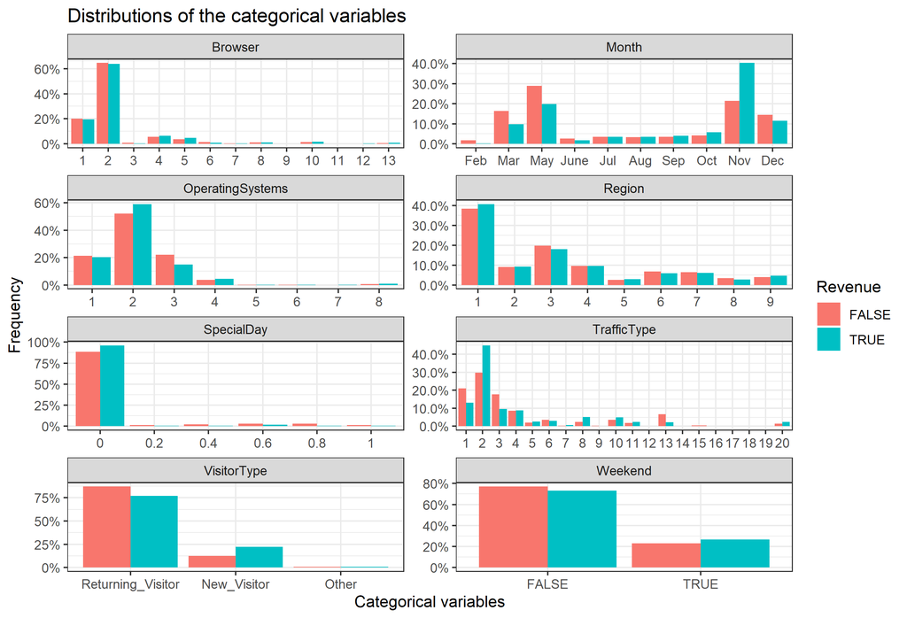

Distribution of Categorical Predictors

### Continuous Variables

> The panels of violin plots below show the distributions of the 7 continuous variables in the dataset. All the variables are highly right skewed, so it is difficult to see the bulk of the distribution since the high outliers are so overpowering in every plot except `ExitRates`. The distributions of these variables between sales and no sales appear to overlap. This may lead to difficulty in distinguishing between the sales and no sales.

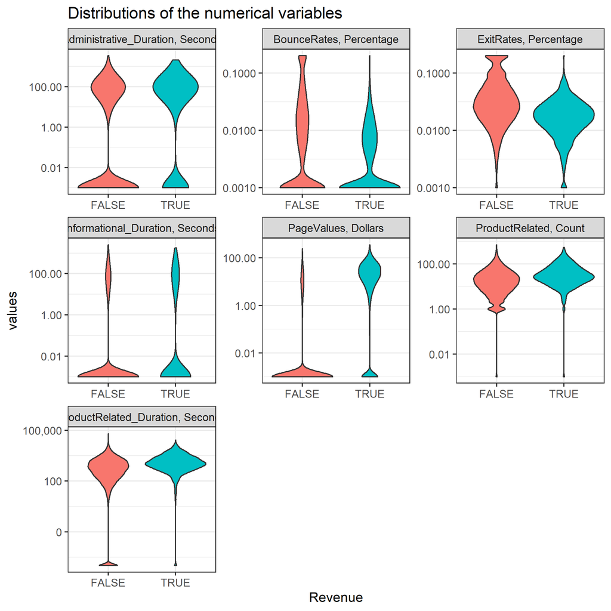

Distribution of Continuous Predictors

## Modelling

> Here we attempted to build a binary classifer that would predict whether an online shopper made a purchase or not. Since this is a classification problem we tried Machine Learning models that are good for classification and tested their accuracy by optimizing the hyperparameters. We mainly tried Python (Van Rossum and Drake 2009)’s Scikit Learn’s (Pedregosa et al. 2011) [Logistic Regression](https://scikit-learn.org/stable/modules/generated/sklearn.linear_model.LogisticRegression.html)(`sklearn.linear_model.LogisticRegression()`), [Random Forest](https://scikit-learn.org/stable/modules/generated/sklearn.ensemble.RandomForestClassifier.html) (`sklearn.ensemble.RandomForest()`) & [Light Gradient Boosting](https://lightgbm.readthedocs.io/en/latest/Python-Intro.html) (`lightgbm.LGBMClassifier()`). The best accuracy on the validation data was achieved by `LGBM`, therefore we went ahead with automating the entire analysis using `LGBM` only.

> We conducted our Exploratory Data Analysis (EDA), in R (R Core Team 2019) and found that the customers who made an online purchase were a small fraction of all the users, ~$15$%). Due to this, there was a possibility of facing the class imbalance issue. To address the potential class imbalance, we included the oversampling strategy (`None`: No oversampling and `balanced`: automatically balancing the weights inversely propotional to the class frequencies) provided by `LGBM` in our hyper-parameter optimization and the modeling framework to automatically decide the most optimal oversampling strategy.

> From the initial EDA, we also saw that the variables had a highly skewed distribution with many outliers. Due to this challenge, we preprocessed the data using [Quantile Transformation](https://scikit-learn.org/stable/modules/generated/sklearn.preprocessing.QuantileTransformer.html) (`sklearn.preprocessing.QuantileTransformation()`) provided by Scikit Learn. This method transforms the individual explanatory variables to follow a normal distribution. This transformation is a robust preprocessing technique and reduces the impact of outliers present in the data.

# Results

## Hyperparameters and Feature Importance

> **Hyperparameters**: The table below displays the best hyperparameters for `LGBM` after performing grid search. The optimal model had a max depth of 5 and 110 tree estimators.

Best Hyperparameters

| Hyperparameter | Value |
| --- | --- |
| class_weight | NA |
| max_depth | 5 |
| n_estimators | 110 |

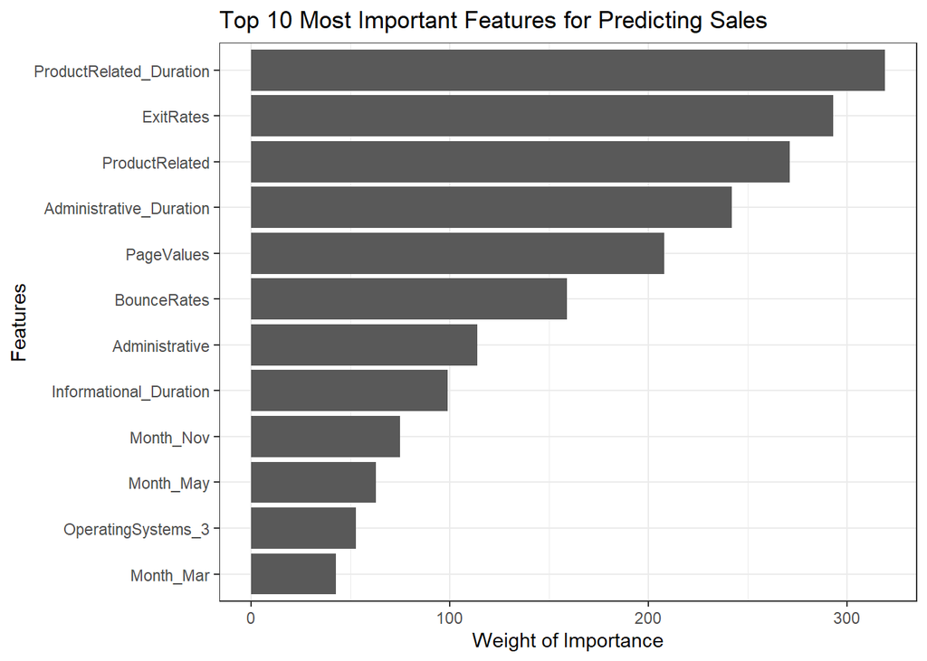

## Model Performance

> We used the confusion matrix, precision, recall, F1, and ROC curve, to evaluate the performance of our model.

> **Confusion Matrix**: Based on the chosen threshold this matrix highlights the classification (True Positives & True Negatives) & misclassifications (False Positives & False Negatives) made by the model. The threshold is automatically chosen by the model based on maximizing the F1-Score. By looking at the confusion matrix we can know the precision, recall & F1-Score of the predictions which gives a holistic view of the performance of the model.

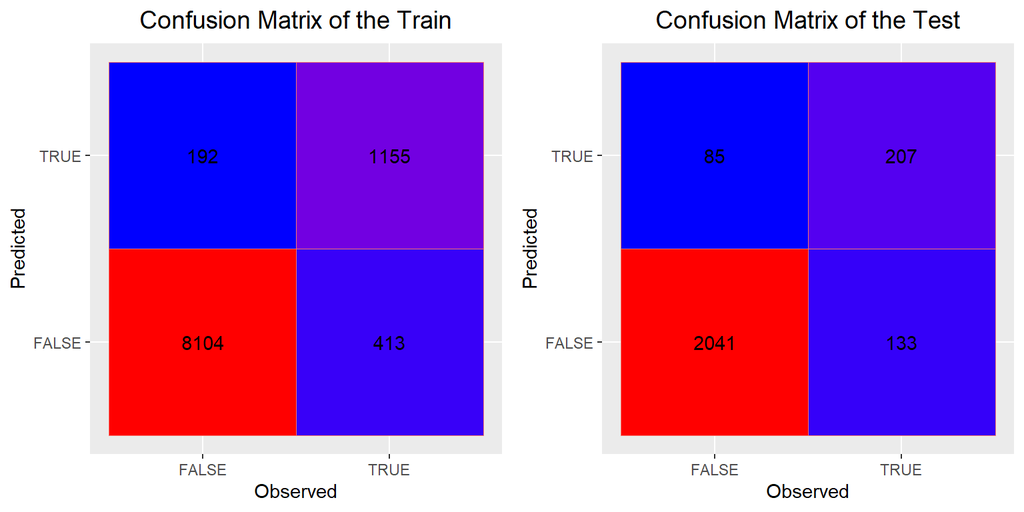

Confusion Matrix

> **Precision & Recall**: The model metrics table below details the performance of the model when classifying a sale or no sale on both the training and the testing data. For the training data, the precision of the model is more than ~85%. The recall is quite a bit lower with the model able to identify around 70% of the true sales. For testing data these corresponding scores are even lower. On the test set, out of the all the predicted sales, more than 65% were correctly identified; and out of the all the true sales the model could only identify ~ 60%.

Model Evaluation Metrics on Train and Test Data

| Dataset | Precision | Recall | F1_Score |
| --- | --- | --- | --- |
| Train | 0.857 | 0.737 | 0.792 |
| Test | 0.709 | 0.609 | 0.655 |

> **ROC-AUC Curve**: Area Under the ROC curve is an apt measure of model performance because it doesn’t depend on the threshold chosen for classifying the predicted class.

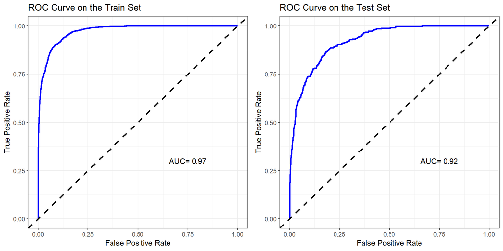

## Choosing an Optimal Threshold

> **Effect of Threshold on Performance**: Deciding the threshold of the predicted probability for classification requires human intervention because sometimes the objective is not only maximizing the accuracy. For e.g. a business might want to decide a threshold that minimizes their cost which is a function of (True/False Positive/Negative). Therefore, we are producing this output which highlights how the performance of the model will change by changing the threshold which can help the stakeholders decide on the optimum threshold.

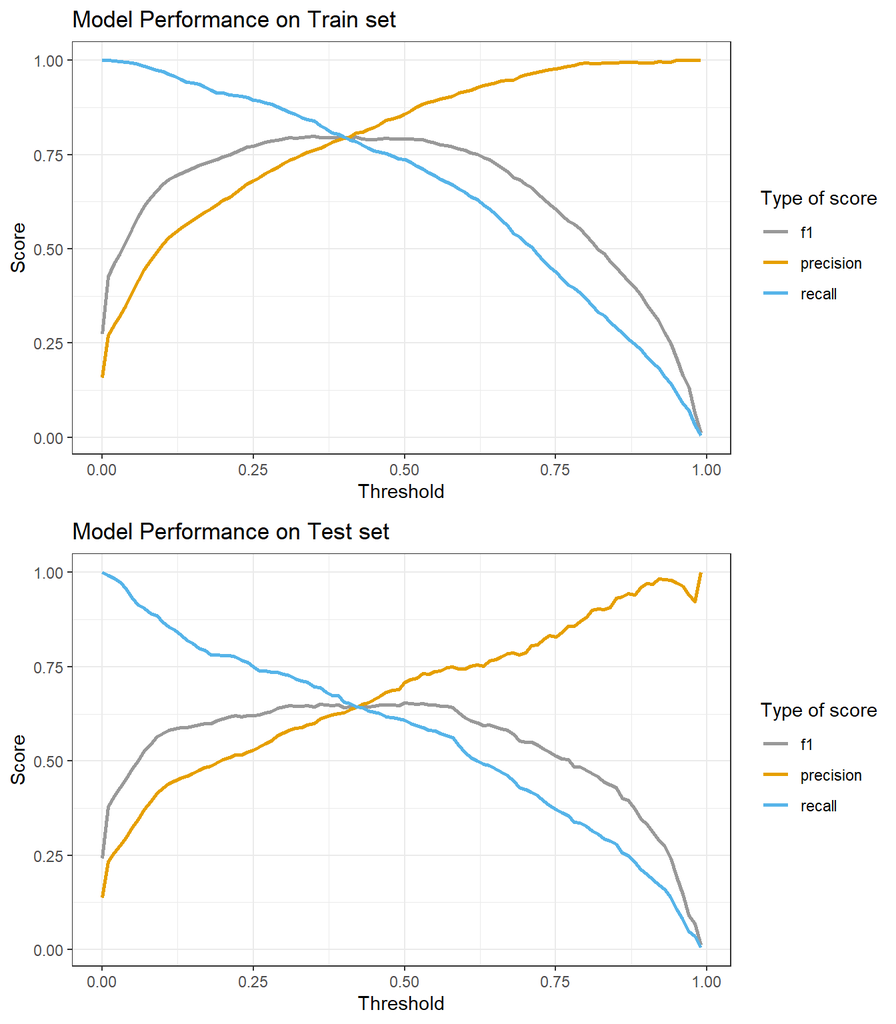

# Limitations

> This dataset contained only ~15% of the class of interest, namely online sales. Such a low proportion of sales examples in the data may be contributing to the low precision and recall on the test set. There was also no feature selection performed which may have resulted in a great number of irrelevant features being retained in the model.

# Future Directions

> Future improvements to the model might include performing `Recursive Feature Elimination` to remove features that are least associated with predicting sales.

# References

Dua, Dheeru, and Casey Graff. 2019. “UCI Machine Learning Repository.” University of California, Irvine, School of Information; Computer Sciences. http://archive.ics.uci.edu/ml.

Pedregosa, F., G. Varoquaux, A. Gramfort, V. Michel, B. Thirion, O. Grisel, M. Blondel, et al. 2011. “Scikit-Learn: Machine Learning in Python.” *Journal of Machine Learning Research* 12: 2825–30.

R Core Team. 2019. *R: A Language and Environment for Statistical Computing*. Vienna, Austria: R Foundation for Statistical Computing. https://www.R-project.org.

Sakar, C Okan, S Olcay Polat, Mete Katircioglu, and Yomi Kastro. 2019. “Real-Time Prediction of Online Shoppers’ Purchasing Intention Using Multilayer Perceptron and Lstm Recurrent Neural Networks.” *Neural Computing and Applications* 31 (10): 6893–6908.

Van Rossum, Guido, and Fred L. Drake. 2009. *Python 3 Reference Manual*. Scotts Valley, CA: CreateSpace.